# MEP analysis

modelling strategy validation

M. Rolland

21/01/2021

Raison du choix de MEP:

> “Je serais plutôt pour tester un de ceux qui sort dans le papier d’Arianne, au choix : MEP, MBzP ou MnBP. Prends en un au hasard.” e-mail Claire 23/11/20

To do:

- explore the possibility of exposure as long format (cf the paper claire reviewed)

# 1 Intro

On 10/20/2020 we discussed with CP of babylab’s analysis plan (cf meeting notes in project_log.html and model_choice.html). We still had questions regarding multiple exposures in the same model (T2 and T3) and regarding interactions between timing of exposure (T2 and T3) and timing of eyetracker experiment (M5, M12, M24). To finalise our analysis plan we decided to perform the following analysis:

- model for one compound (MEP) at 24 months against mean fixation duration
- do a model with T2, then T3 then T2 + T3
- repeat for M5 and M12
- do a mixed model with M24, M12 and M5
- compare all these results to see if they are coherent and if it makes sense to have a repeated measure model with both exposure measurements
- then add an interaction in the repeated measures model to see if different exposure times have different effects at different ages

# 2 Descriptive

## 2.1 MEP

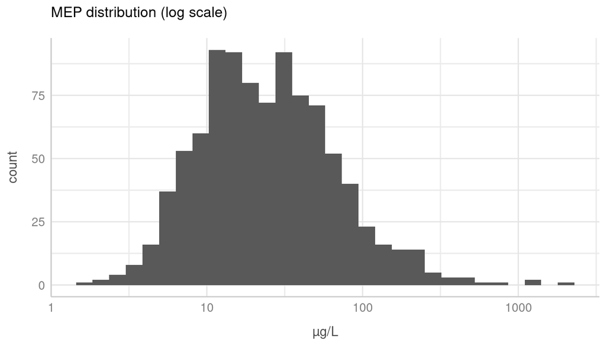

=> MEP looks log noramal(-ish), will include as log in the model

## 2.2 Mean fixation duration

Arithmetic mean of “mean fixation duration” at face recognition and scene exploration tasks:

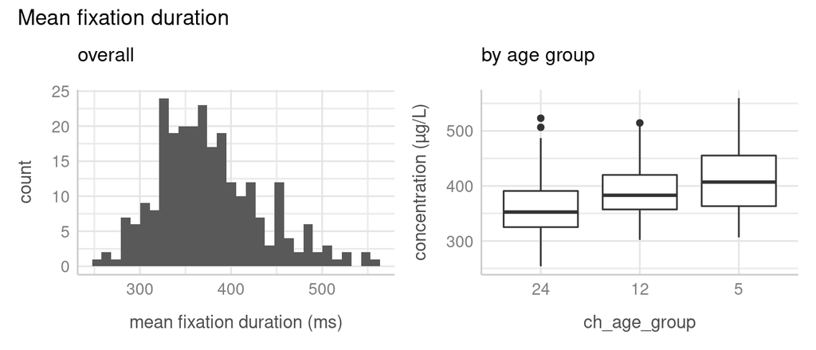

- clear difference with age

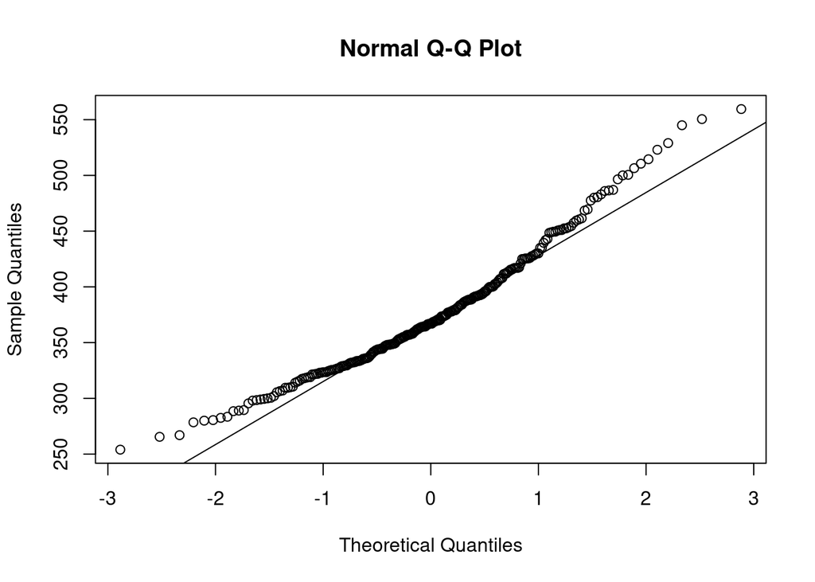

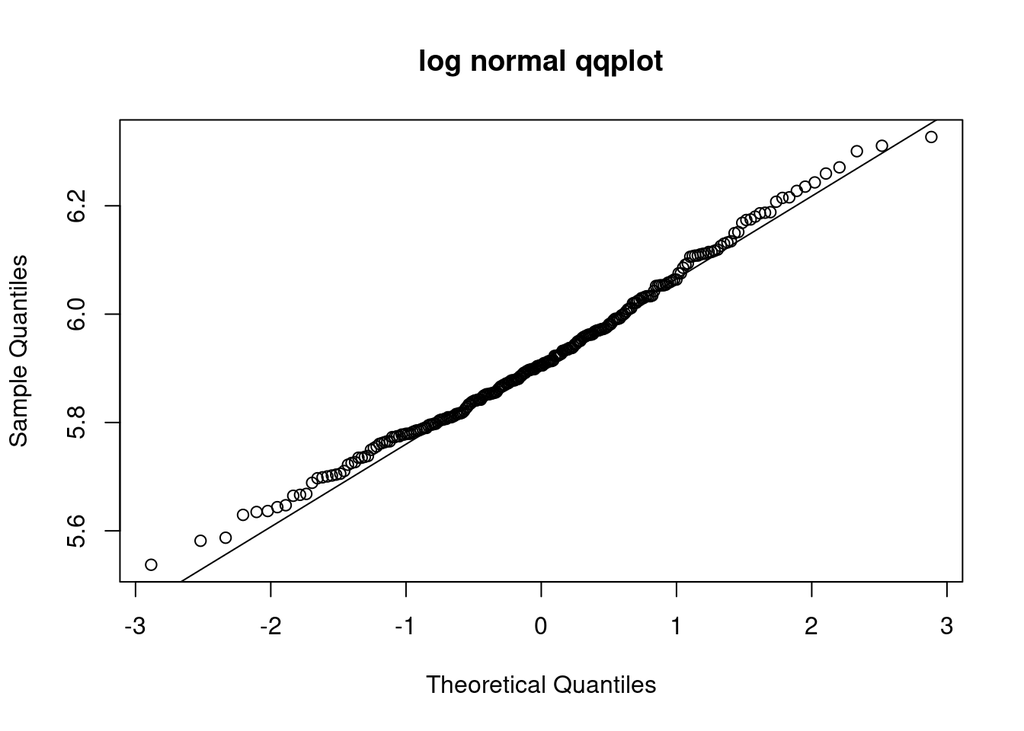

- better log transformed (may want to at least do sensitivity analyses on the log transformed)

## 2.3 Covariates

Final covariates (see `dag_var_coding.html` for more info on variable selection and coding):

- child sex
- tobacco
- maternal age
- experiment time

# 3 Models

For values and p vals check annex.

## 3.1 Compared models

Mixed effect model for all age groups combined (repeated measures):

1. fix_dur ~ ln(MEP_t2) + age_group + covariates + 1|ident
2. fix_dur ~ ln(MEP_t3) + age_group + covariates + 1|ident
3. fix_dur ~ ln(MEP_t2) + ln(MEP_t3) + age_group + covariates + 1|ident

Mixed effect model with interaction term to combine age groups (repeated measures) and take into account possible differences in effect between time of exposure and age of measurement:

1. fix_dur ~ ln(MEP_t2) + age_group + covariates + ln(MEP_T1) * age_group + 1|ident
2. fix_dur ~ ln(MEP_t3) + age_group + covariates + ln(MEP_T3) * age_group + 1|ident
3. fix_dur ~ ln(MEP_t2) + ln(MEP_t3) + age_group + covariates + ln(MEP_t2) * age_group + covariates + ln(MEP_t3) * age_group + 1|ident

## 3.2 Simple models

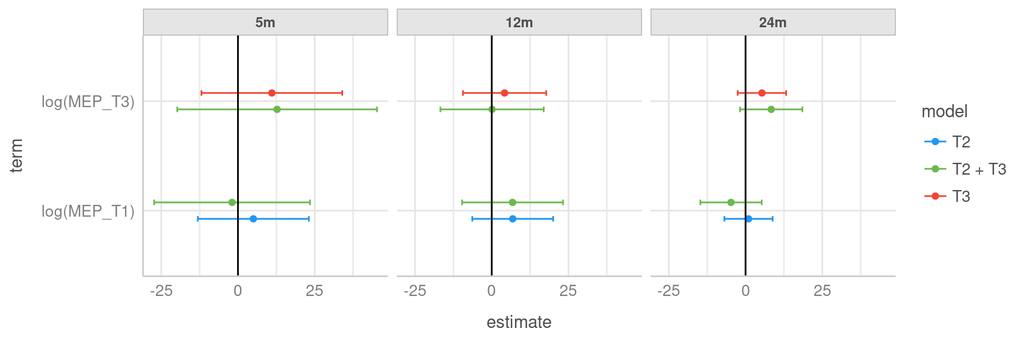

- T2 + T3 model not totally consistent with the separate T2 and T3 models and confidence intervals are wider in the T2 + T3 models => **we will focus on the separate T2 and T3 models**
- effect consistent over age group for the separated T2 and T3 models
  - this would be the green flag for a mixed model effect without interaction

## 3.3 Mixed effect models

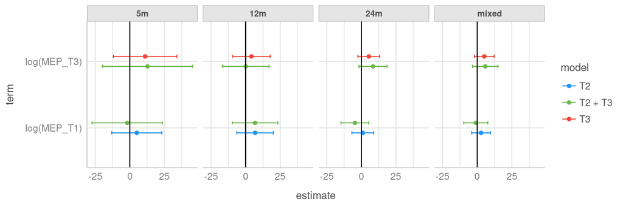

- Mixed model estimates consistent with separate age group estimates **with smaller ICs**
- Confirms there is a gain of power without issues regarding interpretation by doing the mixed effects model

## 3.4 Model with interactions

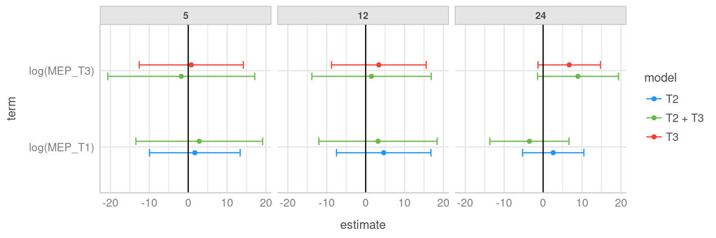

- Results consistent with the mixed model
- Mainly driven by 24m data
- Is this enough to discard interactions for this model?

## 3.5 Conclusions

We will use mixed models as they provide a gain of power by using available data. We will separate T2 and T3 measures as they are correlated which causes estimation issues (inconsistant estimations and larger CIs). We will first do model with interactions and re-run without interaction if interaction non significant.

We will perform the following sensitivity/complementary analyses:

- linear regression separated by age group
- measurement error model
- log(outcome)?

# 4 Annex

## 4.1 Model values

```
## # A tibble: 16 x 6
##    term        estimate conf.low conf.high model   age
##    <chr>          <dbl>    <dbl>     <dbl> <chr>   <fct>
##  1 log(MEP_T1)    0.968    -6.89      8.82 T2      24m
##  2 log(MEP_T3)    5.34     -2.55     13.2  T3      24m
##  3 log(MEP_T3)    8.36     -1.80     18.5  T2 + T3 24m
##  4 log(MEP_T1)   -4.74    -14.7       5.26 T2 + T3 24m
##  5 log(MEP_T1)    6.83     -6.34     20.0  T2      12m
##  6 log(MEP_T3)    4.18     -9.39     17.8  T3      12m
##  7 log(MEP_T3)    0.101   -16.7      16.9  T2 + T3 12m
##  8 log(MEP_T1)    6.78     -9.67     23.2  T2 + T3 12m
##  9 log(MEP_T1)    5.01    -13.1      23.1  T2      5m
## 10 log(MEP_T3)   11.1     -11.9      34.0  T3      5m
## 11 log(MEP_T3)   12.8     -19.8      45.3  T2 + T3 5m
## 12 log(MEP_T1)   -1.91    -27.3      23.5  T2 + T3 5m
## 13 log(MEP_T1)    2.78     -3.97      9.52 T2      mixed
## 14 log(MEP_T3)    5.06     -2.05     12.2  T3      mixed
## 15 log(MEP_T3)    5.82     -3.40     15.0  T2 + T3 mixed
## 16 log(MEP_T1)   -1.03     -9.72      7.66 T2 + T3 mixed
```

## 4.2 Model diagnostics

Models seem OK except there is one outlier according to cook’s distance, the child that was seen at 8AM. Should do sensitivity analysis without outliers (I did it, results are the same).

### 4.2.1 T2 model

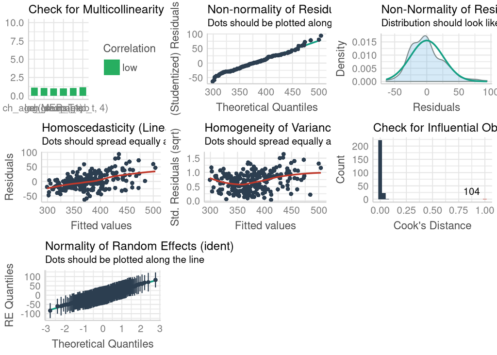

Outlier:

Corresponds to the following:

```
## # A tibble: 1 x 8
##   ident ch_age_group MEP_T1 ch_sex mo_tob mo_age exp_t fix_dur
##   <chr> <fct>         <dbl> <fct>  <fct>   <dbl> <int>   <dbl>
## 1 25773 24             22.3 2      0        32.2     8     307
```

### 4.2.2 T3 model

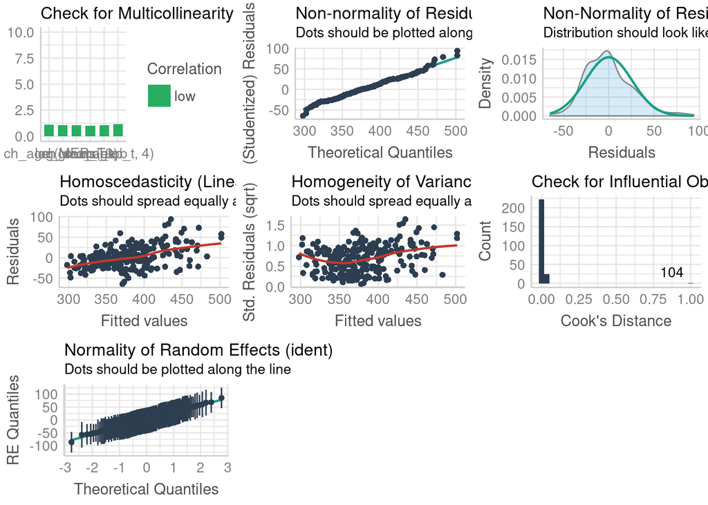

Same outlier as T2 model